# Propiedades de la población

Carlos Iván Espinosa

4 de octubre de 2019

# 1 Introducción

Nosotros como individuos que tan consientes somos de pertenecer a un grupo más grande de individuos, una población, y que de una u otra manera las características de ese grupo tiene un efecto sobre lo que nos pasa a nosotros individualmente. Pensemos en una propiedad del individuo la cantidad de hijos, es igual la cantidad de hijos que ahora tienen las parejas en relación a lo que tenían los abuelos de estas. Al igual que la población humana, las poblaciones de otros organismos tienen efectos sobre los organismos y esos efectos a su vez tienen un impacto sobre las propiedades de la población. Durante los últimos años los cambios que se están suscitando alrededor del planeta están afectando a las poblaciones de diversas especies. Poder entender como una población responde a esas presiones es fundamental si queremos emprender acciones de conservación. Este análisis pasa por la posibilidad de describir eficientemente la población; ¿Dónde se puede establecer la población? ¿Cuál es la abundancia de esa población bajo determinadas condiciones? En el presente ejercicio trabajaremos en comprender las herramientas existentes para realizar la caracterización de la comunidad y sobre todo en desarrollar habilidades para realizar una interpretación biológica de esa caracterización. Una primera restricción a la cual se enfrentan los organismos es el ambiente. Las condiciones ambientales restringe donde una población puede establecerse. La capacidad de adaptación al ambiente que tienen las diferentes especies define los rangos de distribución, hay algunos animales que tienen rangos amplios de distribución y otros que tienen unos rangos restringidos. De esta forma el ambiente determina en primera medida la *distribución geográfica* de una especie, su *nicho fundamental*. Una vez la población se ha establecido, una propiedad importante es su tamaño poblacional, la *abundancia poblacional*. La abundancia de la población está definida por dos factores, por un lado, el rango de distribución y por el otro la *densidad de la población*. La distribución en el espacio de la población no es necesariamente homogéneo y este depende de la escala a la cual estemos midiendo. De esta forma, las poblaciones ocupan el espacio generando un *patrón espacial*, que a su vez determina la densidad y la abundancia.

# 2 Distribución geográfica

Como mencionamos anteriormente la distribución geográfica de una población está definida en primera medida por las condiciones ambientales, las especies ocurren ahí donde las condiciones macro-climáticas le permiten estar. Sin embargo, las especies no necesariamente se encuentran ocupando todo ese espacio, otros factores pueden limitar su distribución. Las barreras geográficas, por ejemplo, limitan las áreas que estas especies pueden realmente ocupar. Adicionalmente, las especies pueden ser excluidas de sitios ambientalmente adecuados por competencia con otras especies.

Durante los últimos años se han desarrollado múltiples modelos de distribución espacial (SDM por sus siglas en ingles) que permiten a partir de unos datos de ocurrencia generar modelos de distribución espacial. A continuación les presento una serie de pasos que permitirá desarrollar modelos de distribución espacial. El presente ejercicio está basado en el Blog *Spatial Data Science* de [Robert Hijmans](https://rspatial.org/raster/sdm/index.html)

## 2.1 Preparación de datos

Una de las fases primordiales para el desarrollo de un *SDM* son los datos de partida. Para poder implementar un modelo necesitamos obtener datos de ocurrencia (coordenadas espaciales), donde la especie ha sido catalogada. Existen múltiples bases de datos con *información de ocurrencia*, pero también los investigadores podrían tener puntos de ocurrencia levantados por ellos mismos. Una vez que se obtienen los datos, es necesario verificar que las coordenadas no sean erradas o que existan problemas con estos datos de ocurrencia, necesitamos *limpiar los datos*.

### 2.1.1 Importando datos de ocurrencia

Cuando el investigador cuenta con datos de ocurrencia levantados por él o que ha levantado de diversas fuentes, necesitamos leerlo en R. Vamos a utilizar datos de un murciélago vampiro que ocurre en las áreas tropicales y que ha sido bastante conocido por atacar al ganado. El nombre científico de esta especie es *Desmodus rotundus*.

```r
library(readxl)

desmod <- read_excel("Ocurrencia Desmodus.xlsx")
```

Ahora verificamos que los datos hayan sido leídos adecuadamente.

```r
str(desmod)
```

```
## Classes 'tbl_df', 'tbl' and 'data.frame':    251 obs. of  3 variables:
##  $ lat: num  -4.63 -4.56 -4.56 -4.51 -4.48 ...
##  $ lon: num  -79.5 -79.5 -79.5 -79.5 -80.4 ...
##  $ ID : num  170591 170114 170114 170921 168803 ...
```

La función *str* nos permite ver las propiedades de la matriz de datos leída. Como vemos tenemos 251 registros y tres variables, latitud, longitud y un identificador.

Ahora es posible que estemos iniciando el trabajo de modelado por lo que no disponemos de datos de ocurrencias, podríamos cargar los datos que han sido depositados en el [Global Biodiversity Inventory Facility (GBIF)](https://www.gbif.org/) usando la función *gbif* del paquete **dismo**. Si es la primera vez que usará este paquete seguramente tendrá que descargarlo; use la siguiente línea de código para hacerlo: `install.packages(“dismo”)`

```r
library(dismo)
# Usar las dos líneas de código a continuación para extraer
#los datos de GBIF y guardarlos en su computador

#La siguiente línea extrae los datos
# desGbif <- gbif("Desmodus", "rotundus", geo = TRUE)

#La siguiente línea graba los datos en su disco duro
# write.csv(desGbif, "desGbif.csv")

#La siguiente vez que realice el trabajo, ejecute solo leer los datos del disco duro

desGbif <- read.csv("desGbif.csv")
```

Pueden ver otros argumentos posibles a usarse con la función GBIF, se podría usar un shape o un polígono para obtener los datos de una región que no interese. A continuación generamos un mapa con el fin de verificar que los puntos tengan una ubicación correcta.

> **Nota:** se puede utilizar la función *getData* para obtener un Shapefile de un lugar que nos interese por ejemplo Ecuador o la función *shapefile* si queremos cargar un Shape que ya tengamos en el computador. Estas dos funciones se encuentran en el paquete **raster**

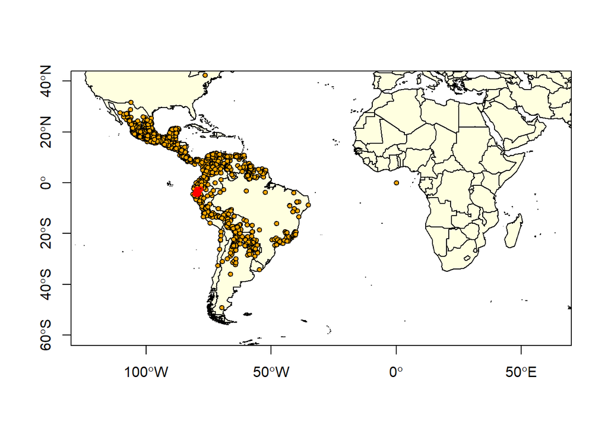

```r
library(maptools)
data(wrld_simpl)
#graficamos un mapa del mundo
plot(wrld_simpl, xlim=c(-100,40), ylim=c(-60,40), axes=TRUE, col="light yellow")
box()
# Adicionamos los puntos de ocurrencia
points(desGbif$lon, desGbif$lat, bg='orange', pch=21, cex=0.75)
# plot points again to add a border, for better visibility
points(desmod$lon, desmod$lat, col='red', cex=0.75)
```